# Summarized Experiment

## Información

El obsejto sumarized experiment es un objeto que posee que se divide en 3 apartados rowData, colData y assay. En los cuales habran diferentes campos que proporcionen la información acerca del estudio de RNA-Seq.

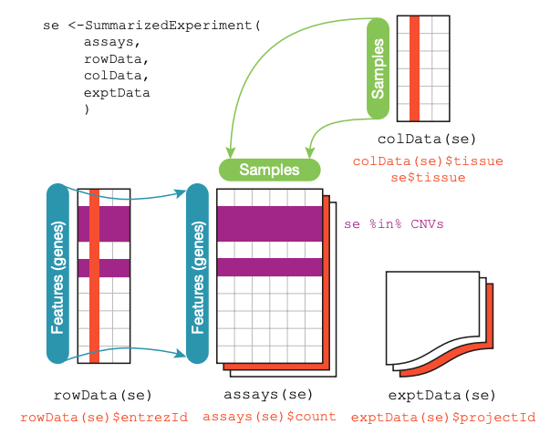

En la parte de **metadata** puede ir lo que uno quiera, es equivalente a un espacio extra para guardar información adicional del experimento.

## Ejemplo

Cargamos la libreria para formar los objetos de summarized experiment

```r
## Lets build our first SummarizedExperiment object
library("SummarizedExperiment")
```

Generamos un ejemplo de las muestras en un estudio de RNA con lo cual podremos generar el objeto de summarized experiment.

```r
## Creamos los datos para nuestro objeto de tipo SummarizedExperiment
## para 200 genes a lo largo de 6 muestras

nrows <- 200
ncols <- 6
## Números al azar de cuentas
set.seed(20210223)
counts <- matrix(runif(nrows * ncols, 1, 1e4), nrows)
## Información de nuestros genes
rowRanges <- GRanges(
    rep(c("chr1", "chr2"), c(50, 150)),
    IRanges(floor(runif(200, 1e5, 1e6)), width = 100),
    strand = sample(c("+", "-"), 200, TRUE),
    feature_id = sprintf("ID%03d", 1:200)
)

# Información de los renglones
names(rowRanges) <- paste0("gene_", seq_len(length(rowRanges)))

## Información de nuestras muestras
colData <- DataFrame(
    Treatment = rep(c("ChIP", "Input"), 3),
    row.names = LETTERS[1:6]
)
## Juntamos ahora toda la información en un solo objeto de R
rse <- SummarizedExperiment(
    assays = SimpleList(counts = counts),
    rowRanges = rowRanges,
    colData = colData
)

## Exploremos el objeto resultante
rse
```

```
## class: RangedSummarizedExperiment
## dim: 200 6
## metadata(0):
## assays(1): counts
## rownames(200): gene_1 gene_2 ... gene_199 gene_200
## rowData names(1): feature_id
## colnames(6): A B ... E F
## colData names(1): Treatment
```

Observamos las dimensiones resultantes de nuestro objeto, por lo que podemos ver que posee 200 genes y 6 muestras distintas

```r
## Número de genes y muestras
dim(rse)
```

```
## [1] 200   6
```

Vemos los genes que se encuentran en nuestro objeto.

```r
## IDs de nuestros genes y muestras
dimnames(rse)
```

```
## [[1]]
##   [1] "gene_1"   "gene_2"   "gene_3"   "gene_4"   "gene_5"   "gene_6"
##   [7] "gene_7"   "gene_8"   "gene_9"   "gene_10"  "gene_11"  "gene_12"
##  [13] "gene_13"  "gene_14"  "gene_15"  "gene_16"  "gene_17"  "gene_18"
##  [19] "gene_19"  "gene_20"  "gene_21"  "gene_22"  "gene_23"  "gene_24"
##  [25] "gene_25"  "gene_26"  "gene_27"  "gene_28"  "gene_29"  "gene_30"
##  [31] "gene_31"  "gene_32"  "gene_33"  "gene_34"  "gene_35"  "gene_36"
##  [37] "gene_37"  "gene_38"  "gene_39"  "gene_40"  "gene_41"  "gene_42"
##  [43] "gene_43"  "gene_44"  "gene_45"  "gene_46"  "gene_47"  "gene_48"
##  [49] "gene_49"  "gene_50"  "gene_51"  "gene_52"  "gene_53"  "gene_54"
##  [55] "gene_55"  "gene_56"  "gene_57"  "gene_58"  "gene_59"  "gene_60"
##  [61] "gene_61"  "gene_62"  "gene_63"  "gene_64"  "gene_65"  "gene_66"
##  [67] "gene_67"  "gene_68"  "gene_69"  "gene_70"  "gene_71"  "gene_72"
##  [73] "gene_73"  "gene_74"  "gene_75"  "gene_76"  "gene_77"  "gene_78"
##  [79] "gene_79"  "gene_80"  "gene_81"  "gene_82"  "gene_83"  "gene_84"
```

[output cut: 23 more lines]

Vemos los valores que poseen los ensayos en el analisis

```r
## Nombres de tablas de cuentas que tenemos (RPKM, CPM, counts, logcounts, etc)
assayNames(rse)
```

```
## [1] "counts"
```

Observamos la tabla con los valores de cada gen en cada muestra.

```r
## El inicio de nuestra tabla de cuentas
head(assay(rse))
```

```
##               A        B         C         D         E        F
## gene_1 2577.960 8526.615 2226.3070 3615.8967 1723.8851 3267.954
## gene_2 7793.183 3462.579  478.2716 7688.3839  295.2813 2698.921
## gene_3 9571.769 5280.564 9772.1671 9916.0076 2621.2085 6880.067
## gene_4 4641.969 2784.091 6670.6757  258.5218 2771.8970 8737.586
## gene_5 6436.758 7053.276 9978.8199 3588.1194 1447.9821 7290.890
## gene_6 6845.704 1502.045 4383.5686 9750.8286 3529.3153 2192.060
```

Vemos los valores guardados en rowData por lo que podremos observar toda la información por default y la extra agregada.

```r
## Información de los genes en un objeto de Bioconductor
rowRanges(rse)
```

```
## GRanges object with 200 ranges and 1 metadata column:
##            seqnames        ranges strand |  feature_id
##               <Rle>     <IRanges>  <Rle> | <character>
##     gene_1     chr1 286235-286334      + |       ID001
##     gene_2     chr1 586770-586869      - |       ID002
##     gene_3     chr1 577897-577996      + |       ID003
##     gene_4     chr1 494350-494449      + |       ID004
##     gene_5     chr1 686692-686791      - |       ID005
##        ...      ...           ...    ... .         ...
##   gene_196     chr2 804998-805097      - |       ID196
##   gene_197     chr2 177462-177561      - |       ID197
##   gene_198     chr2 649993-650092      - |       ID198
##   gene_199     chr2 275940-276039      - |       ID199
##   gene_200     chr2 487418-487517      + |       ID200
##   -------
##   seqinfo: 2 sequences from an unspecified genome; no seqlengths
```

Accedemos a la información de rowData en donde podemos ver el campo extra en los renglones.

```r
## Tabla con información de los genes
rowData(rse) # es idéntico a 'mcols(rowRanges(rse))'
```

```
## DataFrame with 200 rows and 1 column
##           feature_id
##          <character>
## gene_1         ID001
## gene_2         ID002
## gene_3         ID003
## gene_4         ID004
## gene_5         ID005
## ...              ...
## gene_196       ID196
## gene_197       ID197
## gene_198       ID198
## gene_199       ID199
## gene_200       ID200
```

Vemos la información contenida en la sección de colData

```r
## Tabla con información de las muestras
colData(rse)
```

```
## DataFrame with 6 rows and 1 column
##     Treatment
##   <character>
## A        ChIP
## B       Input
## C        ChIP
## D       Input
## E        ChIP
## F       Input
```

### Pregunta de Athena

¿Como extraeriamos los cromosomas del objeto?

```r
## Ver los "unique" levels (cromosomas)
seqlevels(rse)
```

```
## [1] "chr1" "chr2"
```

```r
## Tabla comprimida por repetición de cada level (chromosoma)
seqnames(rowRanges(rse))
```

```
## factor-Rle of length 200 with 2 runs
##   Lengths:   50  150
##   Values : chr1 chr2
## Levels(2): chr1 chr2
```

## Ejercicio

```r
## Comando 1
rse[1:2, ]
```

```
## class: RangedSummarizedExperiment
## dim: 2 6
## metadata(0):
## assays(1): counts
## rownames(2): gene_1 gene_2
## rowData names(1): feature_id
## colnames(6): A B ... E F
## colData names(1): Treatment
```

```r
head(assay(rse[1:2, ]))
```

```
##               A        B         C        D         E        F
## gene_1 2577.960 8526.615 2226.3070 3615.897 1723.8851 3267.954
## gene_2 7793.183 3462.579  478.2716 7688.384  295.2813 2698.921
```

El primer comando lo que hace es que mantiene fijo los renglones 1,2 los cuales equivalen al gen_1 y gen_2, proporcionando la información para todas las columnas.

En este caso podriamos pensarlo como la vista de todas las condiciones para los genes 1 y 2

```r
## Comando 2
rse[, c("A", "D", "F")]
```

```
## class: RangedSummarizedExperiment
## dim: 200 3
## metadata(0):
## assays(1): counts
## rownames(200): gene_1 gene_2 ... gene_199 gene_200
## rowData names(1): feature_id
## colnames(3): A D F
## colData names(1): Treatment
```

```r
head(assay(rse[, c("A", "D", "F")]))
```

```
##               A         D        F
## gene_1 2577.960 3615.8967 3267.954
## gene_2 7793.183 7688.3839 2698.921
## gene_3 9571.769 9916.0076 6880.067
## gene_4 4641.969  258.5218 8737.586
## gene_5 6436.758 3588.1194 7290.890
## gene_6 6845.704 9750.8286 2192.060
```

Por otro lado el segundo comando se encarga de fijar especificamente las columnas A,D,F para todos los renglones.

En este caso podemos interpretarlo como una visión de todos los genes para las muestras A,D,F, generando el subconjunto.

# iSEE

Sirve para la visualización de un objeto de summarized experiment

## Ejemplo

```r
## Explora el objeto rse de forma interactiva
library("iSEE")
```

Por medio de iSEE podemos observar de manera interactiva toda la información del objeto.

```r
# Abrimos el objeto con iSEE
iSEE::iSEE(rse)
```

# SpatialLIBD

Esto genera un objeto SingleCell experiment, por lo que podemos observar la información con un objeto parecido al summarized experiment

## Ejemplo

```r
## Descarguemos unos datos de spatialLIBD
sce_layer <- spatialLIBD::fetch_data("sce_layer")
```

Observamos el resultado del objeto spatial, podemos ver qu de igual manera podemos observar los renglones y las columnas

```r
sce_layer
```

```
## class: SingleCellExperiment
## dim: 22331 76
## metadata(0):
## assays(2): counts logcounts
## rownames(22331): ENSG00000243485 ENSG00000238009 ... ENSG00000278384
##   ENSG00000271254
## rowData names(10): source type ... is_top_hvg is_top_hvg_sce_layer
## colnames(76): 151507_Layer1 151507_Layer2 ... 151676_Layer6 151676_WM
## colData names(12): sample_name layer_guess ... layer_guess_reordered
##   layer_guess_reordered_short
## reducedDimNames(6): PCA TSNE_perplexity5 ... UMAP_neighbors15 PCAsub
## altExpNames(0):
```

Este objeto tambien podemos visualizarlo con iSEE

```r
iSEE::iSEE(sce_layer)
```

Si queremos acceder a la información de ciertos genes en especifico, colocamos los id como si fueran los indices.

```r
sce_layer[c("ENSG00000168314", "ENSG00000183036", "ENSG00000197971"),]
```

```
## class: SingleCellExperiment
## dim: 3 76
## metadata(0):
## assays(2): counts logcounts
## rownames(3): ENSG00000168314 ENSG00000183036 ENSG00000197971
## rowData names(10): source type ... is_top_hvg is_top_hvg_sce_layer
## colnames(76): 151507_Layer1 151507_Layer2 ... 151676_Layer6 151676_WM
## colData names(13): sample_name layer_guess ...
##   layer_guess_reordered_short sizeFactor
## reducedDimNames(6): PCA TSNE_perplexity5 ... UMAP_neighbors15 PCAsub
## altExpNames(0):
```

Ubicamos los nombres de nuestros genes en el objeto por medio del id

```r
# Ubicamos los nombres de nuestros genes
print('COLDATA')
```

```
## [1] "COLDATA"
```

```r
head(rowRanges(sce_layer[c("ENSG00000168314", "ENSG00000183036", "ENSG00000197971"),])$gene_search)
```

```
## [1] "MOBP; ENSG00000168314" "PCP4; ENSG00000183036" "MBP; ENSG00000197971"
```

Conseguimos los nombres de los genes

```r
# Ubicamos los nombres de nuestros genes
print('COLDATA')
```

```
## [1] "COLDATA"
```

```r
head(rowRanges(sce_layer[c("ENSG00000168314", "ENSG00000183036", "ENSG00000197971"),])$gene_name)
```

```
## [1] "MOBP" "PCP4" "MBP"
```

```r
# creamos el objeto que contenga los 3 genes
sce_obj <- sce_layer[c("ENSG00000168314", "ENSG00000183036", "ENSG00000197971"),]
iSEE::iSEE(sce_layer)
```

Para consultar buenos paquetes de R

https://www.shinyapps.io/